# dispRity ecology demo

Thomas Guillerme

2017-08-11

This demo aims to give a quick overview of the `dispRity` package (v.0.3) for multidimensional ecological analyses. Please refer to [GitHub page](https://github.com/TGuillerme/dispRity) for other vignettes, namely the `dispRity` manual that explains the functions in more detail.

To keep it short, this package allows user to include **all** the dimensions of ordinated matrices (i.e. PCA, MDS, PCO) for statistical analysis rather than just a subset of dimensions.

# Before starting

## Installing `dispRity`

You can install this package easily if you are using the latest version of `R` (> 3.0.0) and `devtools`.

```r
if(!require(devtools)) install.packages("devtools")
install_github("TGuillerme/dispRity", ref = "release")
library(dispRity)
```

## Data

For this example with ecological data we are going to use data from D. McClean (unpubl.). The dataset contains an ordinated matrix of 20 dimensions (columns) for 40 elements (rows). The elements are different experimental plots with discrete variations of nutrient enrichment, depth, and freshwater benthic invertebrates.

```r
## Loading demo and the package data
library(dispRity)

## Setting the random seed for repeatability
set.seed(123)

## Loading the data
data(McClean_data)

## This dataset contains an ordinated matrix (20 dimensions) of the distance
## between 40 experimental plots.
ord_matrix <- McClean_data$ordination

## Create lists of the different factors affecting each experimental plot: treatment and depth.
treatments <- McClean_data$treatment
depth <- McClean_data$depth
```

# A classical two dimensional approach

A classical way to represent this ordinated data would be to use two dimensional plots to look at how the different experimental plots differ in their values for nutrient enrichment, depth, and freshwater benthic invertebrates.

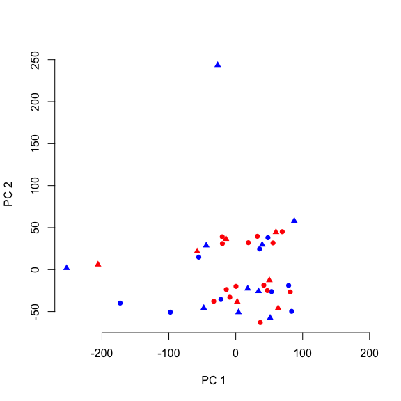

```r
## The x and y axis represent the two first dimensions (principal components) of the ordination
x <- ord_matrix[, 1]
y <- ord_matrix[, 2]
## Setting the colors that will represent the treatments
cols <- sub("a", "red", treatments)
cols <- sub("b", "blue", cols)
## Setting the symbols that will represent the depth
pchs <- sub(1, 16, depth)
pchs <- as.numeric(sub(2, 17, pchs))

## Graphical option
par(bty = "n")
## A classic 2D ordination plot
plot(x, y, col = cols, pch = pchs, xlab = "PC 1", ylab = "PC 2",
     xlim = range(x) + c(0, 100))
```

This shows the distribution of the experimental plots along the two first axis of variation of the ordinated distance matrix (i.e. the first two dimensions). At a first glance, it seems difficult to see a clear effect of the treatments (blue or red) or the depth (rounds or triangles) as the different experimental plots with the same parameters don’t seem to cluster together. However, this may be because this plot ignores the 18 other dimensions of the ordination! Additionally, these two represented dimensions do not represent a biological reality *per se*; i.e. the values on the first dimension do not represent a continuous trait (e.g. depth), instead they just represent the ordinations of correlations between the data and some factors.

Therefore, we might want to approach this problem without getting stuck in only two dimensions and consider the whole dataset as a *n*-dimensional object.

# A multidimensional approach with `dispRity`

## Splitting the data

The first step is to create different subsamples that represent subsamples of the ordinated space (i.e. sub-regions within the *n*-dimensional object). Each of these subsamples will contain a certain number of elements (i.e. a subset of the 40 experimental field plots) that have some attributes in common. In our example, we are going to group the elements according to their depth and treatment.

```r
## Creating the table that contain the elements and their attributes
factors <- as.data.frame(matrix(data = c(treatments, depth), nrow = nrow(ord_matrix),
    ncol = 2, byrow = FALSE, dimnames = list(rownames(ord_matrix))))
names(factors) <- c("Treat", "Depth")
head(factors)
```

```
##     Treat Depth
## 1       a     1
## 1.1     a     2
## 2       b     1
## 2.1     b     2
## 3       a     1
## 3.1     a     1
```

Second, let’s split the data according by depth and treatment to create the subsamples of the ordinated space by using the `custom.subsamples` function:

```r
## Splitting the ordinated space into four subsamples
(customised_subsamples <- custom.subsamples(ord_matrix, factors))
```

```
##  ---- dispRity object ----
## 4 customised subsamples for 40 elements:
##     Treat.a, Treat.b, Depth.1, Depth.2.
```

Note that the output of `dispRity` functions are `dispRity` objects. They allow specific attributes to be displayed using the basic S3 functions (`print`, `summary`, `plot`, etc…). For more details on `dispRity` objects, see the [`dispRity` manual](http://htmlpreview.github.com/?https://github.com/TGuillerme/dispRity/blob/master/doc/dispRity-manual.html).

## Calculating disparity

Disparity can be calculated in many ways, therefore the `dispRity` function allows users to define their own measure of disparity. For more details on measuring disparity, see the [`dispRity` metric vignette](http://htmlpreview.github.com/?https://github.com/TGuillerme/dispRity/blob/master/doc/dispRity-metrics.html).

In this example, we are going to define disparity as the median distance between the different experimental plots and the centroid of the ordinated space. High values of disparity will indicate a generally high spread of points from this centroid (i.e. on average, the experimental plots are far apart in the ordinated space). We can define the metrics easily in the `dispRity` function by feeding them to the `metric` argument. Here we are going to feed the functions `stats::median` and `dispRity::centroids` which calculates distances between elements and their centroid.

```r
## Calculating disparity as the median distance between each elements and their group centroid
(disparity <- dispRity(customised_subsamples, metric = c(median, centroids)))
```

```
##  ---- dispRity object ----
## 4 customised subsamples for 40 elements with 20 dimensions:
##     Treat.a, Treat.b, Depth.1, Depth.2.
## Disparity was calculated as: c(median, centroids).
```

Similarly to the `custom.subsamples` function, `dispRity` displays a `dispRity` object. To actually look at the calculated values, we can summarise the data by simply using `summary`:

```r
## Displaying the summary of the calculated disparity
summary(disparity)
```

```
##   subsamples  n   obs
## 1    Treat.a 21 82.38
## 2    Treat.b 19 94.68
## 3    Depth.1 23 83.98
## 4    Depth.2 17 89.72
```

## Bootstrapping the data

We can also bootstrap the data to test the robustness of the measured disparity to outliers. Also, as we can see, each subsample has different numbers of elements. It might also be interesting to rarefy the data to have only subsamples with the same number of elements. Both steps are easily doable through the `boot.matrix` function.

```r
## Bootstrapping the customised subsamples 100 times
(bootstrapped_data <- boot.matrix(customised_subsamples, bootstraps = 100))
```

```
##  ---- dispRity object ----
## 4 customised subsamples for 40 elements with 20 dimensions:
##     Treat.a, Treat.b, Depth.1, Depth.2.
## Data was bootstrapped 100 times (method:"full").
```

```r
## Bootstrapping the subsamples and using rarefaction
## (i.e. only re-sampling 17 elements each time)
(rarefied_data <- boot.matrix(customised_subsamples, bootstraps = 100, rarefaction = 17))
```

```
##  ---- dispRity object ----
## 4 customised subsamples for 40 elements with 20 dimensions:
##     Treat.a, Treat.b, Depth.1, Depth.2.
## Data was bootstrapped 100 times (method:"full") and rarefied to 17 elements.
```

We can now run a more robust disparity analysis using the bootstrapped data:

```r
## Calculating the bootstrapped disparity
disparity_BS <- dispRity(bootstrapped_data, metric = c(median, centroids))

## Calculating the rarefied disparity
disparity_rare <- dispRity(rarefied_data, metric = c(median, centroids))
```

## Summarising the results

We can now summarise the results using various options such as the confidence intervals and the central tendency. For that we use the `summary` function mentioned above, using several of the options specific to `dispRity` objects (see more details with `?summary.dispRity`).

```r
## Summarising bootstrapped disparity
summary(disparity_BS)
```

```
##   subsamples  n   obs bs.median  2.5%   25%   75% 97.5%
## 1    Treat.a 21 82.38     79.17 64.80 75.49  83.7  99.0
## 2    Treat.b 19 94.68     97.02 79.63 90.00 106.8 138.6
## 3    Depth.1 23 83.98     82.92 68.20 78.86  86.0  94.0
## 4    Depth.2 17 89.72     96.43 75.72 85.87 108.4 176.7
```

```r
## Summarising the rarefied disparity
summary(disparity_rare)
```

```
##   subsamples  n   obs bs.median  2.5%   25%   75% 97.5%
## 1    Treat.a 21 82.38      78.5 67.06 75.29  83.1  95.6
## 2    Treat.a 17    NA      77.8 65.55 73.75  82.1  88.9
## 3    Treat.b 19 94.68      97.6 79.90 88.94 110.0 131.2
## 4    Treat.b 17    NA      94.2 77.98 88.40 111.2 141.8
## 5    Depth.1 23 83.98      81.1 68.47 76.81  84.4  91.5
## 6    Depth.1 17    NA      83.0 67.43 77.85  88.3  96.5
## 7    Depth.2 17 89.72     100.0 77.29 88.35 112.4 159.0
```

```r
## Summarising the same results but using the mean as the central tendency and displaying
## the 90th quantile only.
summary(disparity_rare, quantile = 90, cent.tend = mean)
```

```
##   subsamples  n   obs bs.mean    5%   95%
## 1    Treat.a 21 82.38    79.4 67.97  89.8
## 2    Treat.a 17    NA    78.0 67.30  87.8
## 3    Treat.b 19 94.68   100.4 81.20 125.5
## 4    Treat.b 17    NA   100.5 78.60 136.0
## 5    Depth.1 23 83.98    80.9 70.65  90.9
## 6    Depth.1 17    NA    83.0 69.61  93.6
## 7    Depth.2 17 89.72   103.3 78.71 147.8
```

We can also plot the results and look at the effect of the number of experimental plots using the generic `plot` function and its associated arguments (see more details with `?plot.dispRity` for the arguments specific to `dispRity` objects).

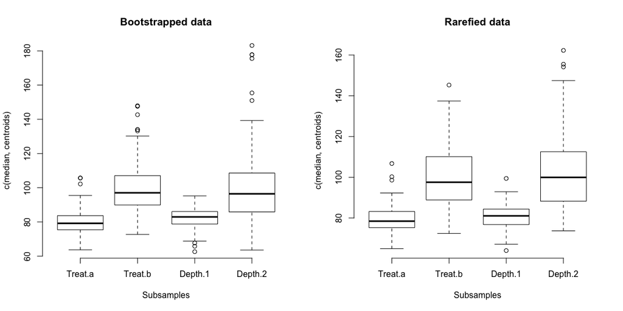

```r
## Graphical options
quartz(width = 10, height = 5) ; par(mfrow = (c(1,2)), bty = "n")

## Plotting the bootstrapped disparity
plot(disparity_BS, main = "Bootstrapped data")

## Plotting the rarefied disparity
plot(disparity_rare, main = "Rarefied data")
```

As we can see, there seems to be no strong effect of the number of experimental plots in each subsample (i.e. the rarefied plot is really similar to the bootstrapped plot) which is a good thing!

## Testing the hypothesis

Finally, we can test our hypothesis (whether the water treatment at certain depths alters invertebrate communities and composition in natural habitats) by using the `test.dispRity` function.

```r
## Testing the effect of our factors on the bootstrapped data
summary(test.dispRity(disparity_BS, test = aov, comparisons = "all"))
```

```
##      Length Class Mode
## [1,] 13     aov   list
```

```r
## Testing the effect of our factors on the rarefied data
summary(test.dispRity(disparity_rare, test = aov, comparisons = "all"))
```

```
##      Length Class Mode
## [1,] 13     aov   list
```

```r
## Post-hoc testing of the effect of the two different factors
## Note that the comparison contains the list of the pairs of subsamples to compare
test.dispRity(disparity_BS, test = wilcox.test, comparisons = list(c(1,2), c(3,4)))
```

```
## [[1]]
##                   statistic
## Treat.a : Treat.b       855
## Depth.1 : Depth.2      1769
##
## [[2]]
##                        p.value
## Treat.a : Treat.b 4.209269e-24
## Depth.1 : Depth.2 2.941391e-15
```

```r
## Testing the effect of the two different factors for the rarefied data
test.dispRity(disparity_rare, test = wilcox.test, comparisons = list(c(1,2), c(3,4)))
```

```
## [[1]]
##                   statistic
## Treat.a : Treat.b       773
## Depth.1 : Depth.2      1246
##
## [[2]]
##                        p.value
## Treat.a : Treat.b 5.320775e-25
## Depth.1 : Depth.2 4.675212e-20
```

As we can see, there is strong support for an effect of the treatment and the depth on the median distance between each experimental plot and the centroid of the ordinated space. In other words, it seems that with the second treatment and the second level of depth, the invertebrate communities and composition were further apart (i.e. more dispersed in the ordinated space) than with the first treatment and the first level of depth.